# Regression Homework

Aaron

June 5, 2016

The homework is from `Verzani`, problems: **13.1,13.2, 13.3, 13.4**

```r
library(ggplot2)
library(dplyr)
library(magrittr)
```

#### Problem 13.1

The cost of a home depends on the number of bedrooms in the house. Suppose the following data is recorded for homes in a given town

Make a scatterplot, and fit the data with a regression line. On the same graph, test the hypothesis that an extra bedroom costs $60,000 against the alternative that it costs more.

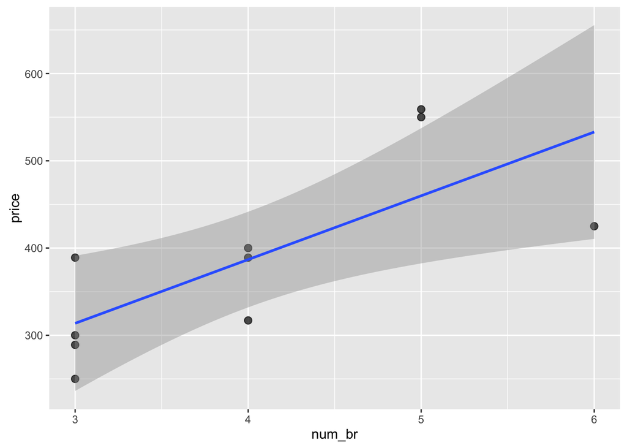

```r
house <- data.frame(price=c(300, 250, 400, 550, 317, 389, 425, 289, 389, 559),
                    num_br=c(3,3,4,5,4,3,6,3,4,5))

house %>%
    ggplot(aes(num_br, price)) +
    geom_point(size=2.5, alpha=0.7) +
    geom_smooth(method = lm)
```

```r
house %>%
    lm(price~num_br,.) -> fit_0
```

**Inferenece about `peta-1`**

```r
n = 10 # # of obs

res = resid(fit_0) # find residual
b1 = (coefficients(fit_0))[[2]] # find beta 1

SE = coefficients(summary(fit_0))[2,2]
t=(b1-60)/SE

pt(t, n-2 ,lower.tail=F)
```

```
## [1] 0.2982602
```

We fail to reject the null hypothesis that an extra bedroom costs **$60,000 (p=.2982602).**

#### Problem 13.2

It is well known that the more beer you drink, the more your blood alcohol level rises. Suppose we have the following data on student beer consumption

Make a scatterplot and fit the data with a regression line. Test the hypothesis that another beer raises your BAL by 0.02 percent against the alternative that it is less.

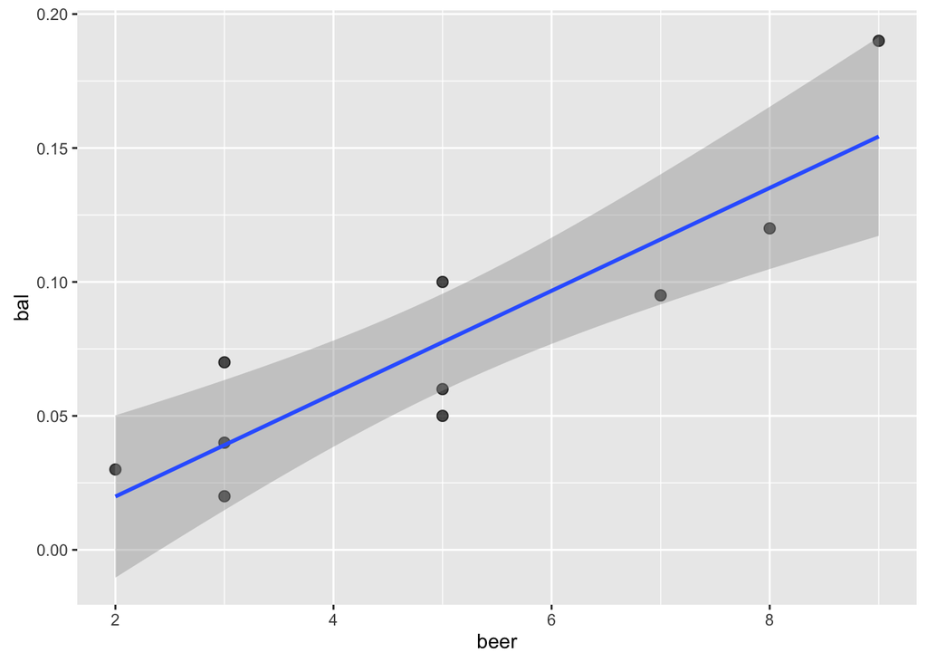

```r
beer <- data.frame(beer = c(5,2,9,8,3,7,3,5,3,5),
                   bal  = c(0.10, 0.03, 0.19, 0.12, 0.04, 0.095, 0.07, 0.06, 0.02, 0.05))

beer %>%
    ggplot(aes(beer, bal)) +
    geom_point(size=2.5, alpha=0.7) +
    geom_smooth(method = lm)
```

```r
beer %>%
    lm(bal ~ beer, .) -> fit_1
```

```r
res = resid(fit_1) # find residual
n = length(res) # find number of obs

b1 = (coefficients(fit_1))[[2]] # find beta 1

SE = coefficients(summary(fit_1))[2,2]

t=(b1-(0.02))/SE

pt(t, n-2 ,lower.tail=TRUE)
```

```
## [1] 0.4127342
```

We fail to reject the null hypothesis that another beer raises your BAL by **0.02 percent (p=0.4127342).**

#### Problem 13.3

For the same Blood alcohol data, do a hypothesis test that the intercept is 0 with a two-sided alternative.

```r
b0 = (coefficients(fit_1))[[1]]

t = (b0 - 0)/SE

p_two_sided = 2*pt(t,n-2,lower.tail=T)

print(paste("the two sided p-value is", round(p_two_sided,5)))
```

```
## [1] "the two sided p-value is 0.00076"
```

#### Problem 13.4

The lapse rate is the rate at which temperature drops as you increase elevation. Some hardy students were interested in checking empirically if the lapse rate of 9.8 degrees C/km was accurate for their hiking. To investigate, they grabbed their thermometers and their Suunto wrist altimeters and found the following data on their hike

```r
lapse <- data.frame(elevation = c(600, 1000, 1250, 1600, 1800, 2100, 2500, 2900),
                    temp = c(56, 54, 56, 50, 47, 49, 47, 45))
```

Draw a scatter plot with regression line, and investigate if the lapse rate is 9.8C/km. (First, it helps to convert to the rate of change in Fahrenheit per feet with is 5.34 degrees per 1000 feet.)

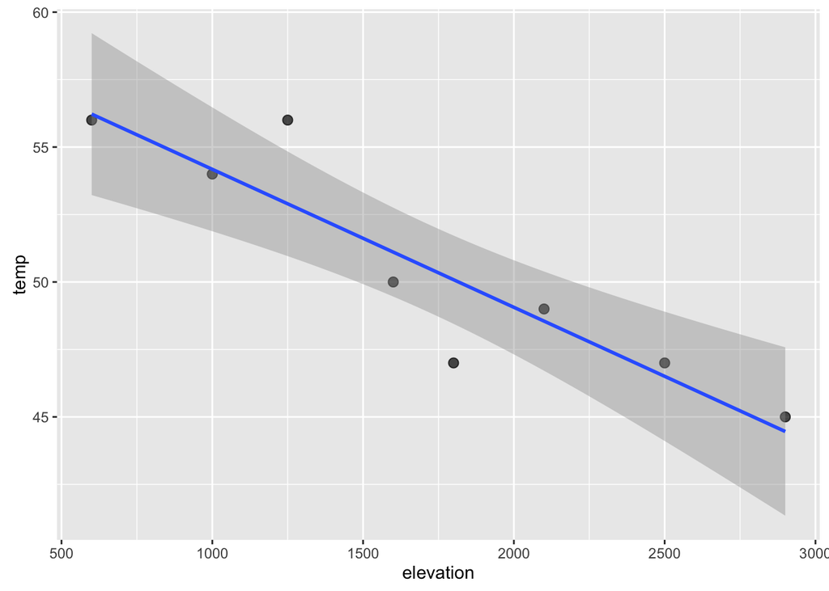

```r
lapse %>%
    ggplot(aes(elevation, temp)) +
    geom_point(size=2.5, alpha=0.7) +
    geom_smooth(method = lm)
```

```r
lapse %>%
    lm(temp ~ elevation, .) -> fit_2


b1 = (coefficients(fit_2))[[2]]
```

Test the hypothesis that the lapse rate is 5.34 degrees per 1000 feet against the alternative that it is less than this.

```r
res = resid(fit_2) # find residual
n = length(res) # find number of obs

b1 = (coefficients(fit_2))[[2]] # find beta 1

SE = coefficients(summary(fit_2))[2,2]

t=(b1-(5.34/1000))/SE

pt(t, n-2 ,lower.tail=TRUE)
```

```
## [1] 1.403103e-05
```